# Eye Tracking Pilot

Steven Vannoy

Report Generated on: 01/31/2016 01:36 PM

This report contains descriptive statistics and analysis tables and figures associated with our pilot study. It is not fully annotated, but intended to give the reviewers a chance to see more details regarding the pilot study that is referred to in the full application.

```
## Visit http://strengejacke.de/sjPlot for package-vignettes.
```

**DEMOGRAPHICS**

Participants By Age

| Variable | Value |
| --- | --- |
| Min. | 18.00 |
| 1st Qu. | 18.00 |
| Median | 20.00 |
| Mean | 23.11 |
| 3rd Qu. | 23.25 |
| Max. | 82.00 |

Participants By Gender

| Gender | count | % |
| --- | --- | --- |
| male | 32 | 36.78 |
| female | 52 | 59.77 |
| decline | 1 | 1.15 |
| unknown | 1 | 1.15 |
| MTF | 1 | 1.15 |

Participants By Sexual Orientation

| Sexual Orientation | count | % |
| --- | --- | --- |
| heterosexual | 75 | 85.23 |
| homosexual | 4 | 4.55 |
| bisexual | 6 | 6.82 |
| queer | 1 | 1.14 |
| decline | 2 | 2.27 |

Participants By Academic Class

| Academic Class | count | % |
| --- | --- | --- |
| freshman | 32 | 36.78 |
| sophomore | 20 | 22.99 |
| junior | 13 | 14.94 |
| senior | 12 | 13.79 |
| masters | 8 | 9.20 |
| doctoral | 1 | 1.15 |
| other | 1 | 1.15 |

Participants By Race

[output not shown]

**DESCRIPTIVES**

PHQ9 Summary

| Variable | Value |
| --- | --- |
| Min. | 0.00 |
| 1st Qu. | 2.00 |
| Median | 4.00 |
| Mean | 6.21 |
| 3rd Qu. | 8.25 |
| Max. | 24.00 |

Participants By Likelihood of Mild Depression

| PHQ-9 > 9 | count | % |
| --- | --- | --- |
| FALSE | 68 | 77.27 |
| TRUE | 20 | 22.73 |

Participants By Likelihood of Major Depression

| PHQ-9 > 14 | count | % |
| --- | --- | --- |
| FALSE | 76 | 86.36 |
| TRUE | 12 | 13.64 |

GAD7 Summary

| Variable | Value |
| --- | --- |
| Min. | 0.00 |
| 1st Qu. | 2.00 |
| Median | 4.00 |
| Mean | 5.48 |
| 3rd Qu. | 8.00 |
| Max. | 19.00 |

Participants By Likelihood of Generalized Anxiety Disorder

| GAD7 > 9 | count | % |
| --- | --- | --- |
| FALSE | 73 | 82.95 |
| TRUE | 15 | 17.05 |

Participants By Frequency of Suicide Ideation

| PHQ-SI | count | % |
| --- | --- | --- |
| 0 | 70 | 79.55 |
| 1 | 13 | 14.77 |
| 2 | 4 | 4.55 |
| 3 | 1 | 1.14 |

Participants By Frequency of Suicide Ideation (Dichotomized yes/no)

| Any PHQ-SI | count | % |
| --- | --- | --- |
| FALSE | 70 | 79.55 |
| TRUE | 18 | 20.45 |

SBQ Summary

| Variable | Value |
| --- | --- |
| Min. | 3.00 |
| 1st Qu. | 3.00 |
| Median | 5.00 |
| Mean | 6.09 |
| 3rd Qu. | 8.00 |
| Max. | 16.00 |

RFL Summary

| Variable | count |
| --- | --- |
| Min. | 49.0 |
| 1st Qu. | 130.8 |
| Median | 143.5 |
| Mean | 144.2 |
| 3rd Qu. | 161.2 |
| Max. | 192.0 |

*VARIABLE CORRELATIONS*

|  | Eye-Track | S-IAT | PHQ-9 | PHQ-SI | GAD-7 | SBQ-R | SBQ-Q1 | SBQ-Q2 | SBQ-Q3 | SBQ-Q4 | SCS | RFL |
| --- | --- | --- | --- | --- | --- | --- | --- | --- | --- | --- | --- | --- |
| Eye-Track |  |  |  |  |  |  |  |  |  |  |  |  |
| S-IAT | 0.068 |  |  |  |  |  |  |  |  |  |  |  |
| PHQ-9 | 0.339* | 0.276 |  |  |  |  |  |  |  |  |  |  |
| PHQ-SI | 0.335* | -0.076 | 0.634*** |  |  |  |  |  |  |  |  |  |
| GAD-7 | 0.322* | 0.343* | 0.909*** | 0.586*** |  |  |  |  |  |  |  |  |
| SBQ-R | 0.186 | 0.268 | 0.552*** | 0.393* | 0.513*** |  |  |  |  |  |  |  |
| SBQ-Q1 | 0.153 | 0.305 | 0.565*** | 0.247 | 0.515*** | 0.895*** |  |  |  |  |  |  |
| SBQ-Q2 | 0.190 | 0.169 | 0.498** | 0.522*** | 0.442** | 0.889*** | 0.725*** |  |  |  |  |  |
| SBQ-Q3 | 0.077 | 0.324* | 0.370* | 0.131 | 0.373* | 0.797*** | 0.655*** | 0.634*** |  |  |  |  |
| SBQ-Q4 | 0.187 | 0.192 | 0.452** | 0.345* | 0.437** | 0.871*** | 0.724*** | 0.642*** | 0.614*** |  |  |  |
| SCS | 0.297 | 0.334* | 0.778*** | 0.599*** | 0.727*** | 0.694*** | 0.645*** | 0.572*** | 0.479** | 0.678*** |  |  |
| RFL | -0.300 | -0.137 | -0.589*** | -0.485** | -0.547*** | -0.650*** | -0.512*** | -0.648*** | -0.445** | -0.589*** | -0.609*** |  |
| Computed correlation used pearson-method with listwise-deletion. |  |  |  |  |  |  |  |  |  |  |  |  |

*REGRESSION FIT*  
We regressed SCS scores onto the ETSAM and S-IAT. Results are presented below. The regression below utilizes the ETSAM settings reflected above in the correlation table. While the ETSAM is not significant at the p < 0.05 level in this regression, we can easily ‘tune’ the measure to make it significant. Doing so also effects the correlation table above, increasing the correlations with all predictors. However, due to concerns of over-fitting, we have not included that setting. Note the width of the confidence intervals, while the S-IAT coefficient is quite large (B=11.56), the confidence interval is also large. Below the regression table you will see two scatter plots, one for the ETSAM and one for the S-IAT plotted against the SCS scores. It is clear in the graphs that the variability of the ETSAM is substantially higher and this variability is influencing the significance level in the regression.

We have analyzed the timing and frequency of fixations across the 8 second exposure for each slide and found that there is no decline in fixations during the exposure (i.e. participants are not fixating frequently at the beginnign of the exposure and then more slowly near the end). For the proposed study, we will increase the duration of slide exposure by 25% (from 8 seconds to 10 seconds), which we believe will stabilize the fixation scores, reducing the variability attributed to small sample size. This will also increase the number of participants who reach the minimum threshold of fixations, reducing the number that must be excluded from the analysis.

|  |  | SCS |  |  |
| --- | --- | --- | --- | --- |
|  |  | B | CI | p |
| (Intercept) |  | 34.84 | 28.88 – 40.80 | **<.001** |
| Eye-Tracking |  | 3.41 | -0.32 – 7.15 | .072 |
| S-IAT |  | 11.56 | 0.50 – 22.61 | **.041** |
| Observations |  | 40 |  |  |
| R<sup>2</sup> / adj. R<sup>2</sup> |  | .187 / .143 |  |  |

*PLOTS*

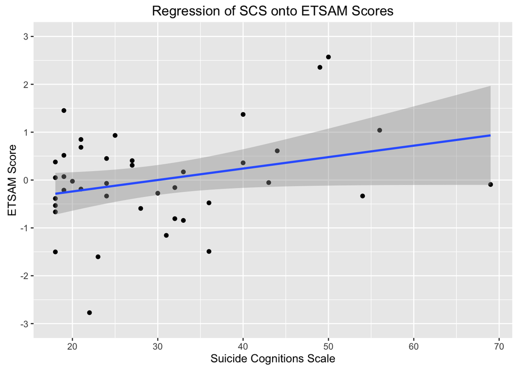

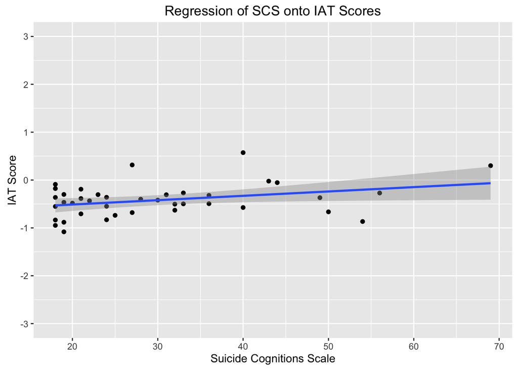

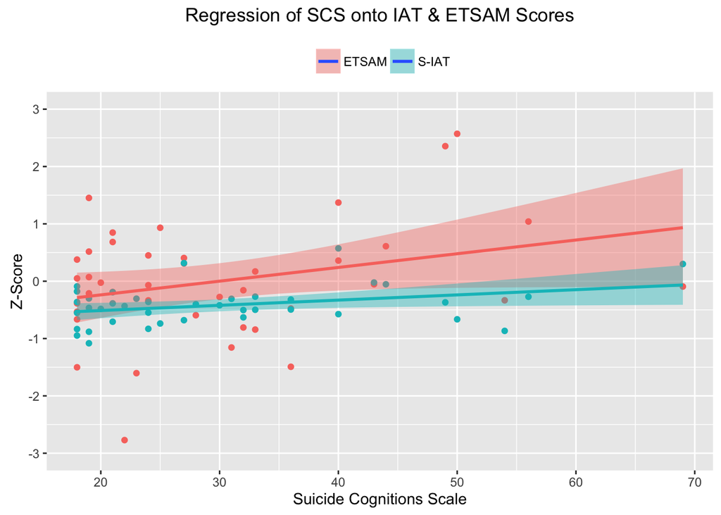